# Lecture X: Bayes, the linear model, and caterpillars.

## Previously…

Topics we got to earlier in the course:

- Linear model from a frequentist point of view
- Review (or intro) to Bayes
- Understanding how to explore data

## Today…

- Bayesian linear model
- Caterpillar data
- Next time: Model selection!

## Linear Model Set up

- Response, \(y = (y_1, \ldots, y_n)\)
- Exploratory variables \(X_{n \times p} = (x_1, \ldots, x_p).\)
- Want to address the linear influence of \(x_j\) on \(y\) once the linear influence has been taken into account (e.g. medical studies)

## Caterpillar Example

- From 1973 study on pine processionary caterpillars
- Assesses the influence of some forest settlement characteristics on the development of caterpillar colonies
- y: logarithmic transform of the average number of nests of caterpillars per tree in an area of 500 \(m^2\)
- p = 8, n = 33

## Explanatory variables (Domain knowledge!!)

- altitude, slope, number of pine trees, height of tree, orientation of area, height of dominant tree, number of vegetation strata, mix settlement index

## What is the goal of regression analysis?

- Decide which explanatory variables have a strong influence on the number of nests.
- How do these influences overlap with one another?

## Let's do some exploring!

- Be sure to load the bayess library

```r
library("bayess")
```

## The caterpillar matrix

```r
data(caterpillar)
caterpillar
```

```
##      x1 x2 x3  x4  x5   x6  x7  x8    y
## 1  1200 22  1 4.0 1.1  5.9 1.4 1.4 2.37
## 2  1342 28  8 4.4 1.5  6.4 1.7 1.7 1.47
## 3  1231 28  5 2.4 1.6  4.3 1.5 1.4 1.13
## 4  1254 28 18 3.0 1.7  6.9 2.3 1.6 0.85
## 5  1357 32  7 3.7 1.7  6.6 1.8 1.3 0.24
## 6  1250 27  1 4.4 1.7  5.8 1.3 1.4 1.49
## 7  1422 37 22 3.0 1.9  8.3 2.5 2.0 0.30
## 8  1309 46  7 5.7 1.3  7.8 1.8 1.6 0.07
## 9  1127 24  2 3.5 1.7  4.9 1.5 2.0 3.00
## 10 1075 34  9 4.3 1.8  6.8 2.0 2.0 1.21
## 11 1166 24 17 5.5 1.5 11.5 2.9 1.7 0.38
## 12 1182 41 32 5.4 1.4 11.3 2.8 2.0 0.70
## 13 1179 15  0 3.2 1.7  4.0 1.1 1.6 2.64
## 14 1256 21  0 5.1 1.8  5.8 1.1 1.4 2.05
```

[output cut: 19 more lines]

```r
y=log(caterpillar$y)
X=as.matrix(caterpillar[,1:8])
data("caterpillar")
```

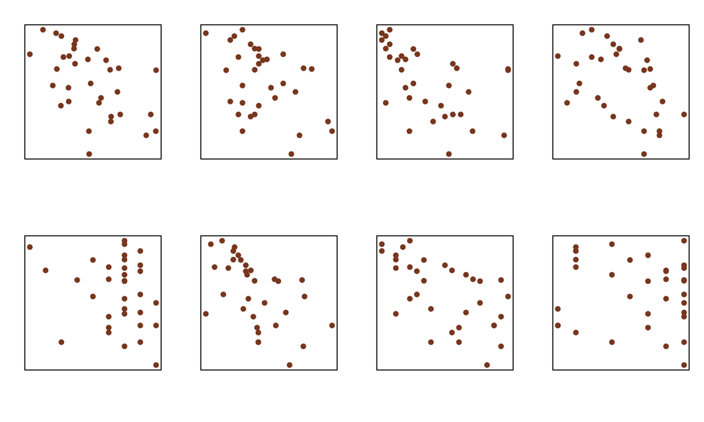

```r
y=log(caterpillar$y)
X=as.matrix(caterpillar[,1:8])
par(mfrow=c(2,4),mar=c(4.2,2,2,1.2))
for (j in 1:8) plot(X[,j],y,xlab="",pch=19,col="sienna4",xaxt="n",yaxt="n")
```

## Linear model

- We assume an ordinary linear regression model \[y \mid \alpha, \beta, \sigma^2 \sim N_n (\alpha 1_n +X\beta, \sigma^2 I_n),\] where \(N_n\) denotes the multivariate normal distribution with dimension \(n.\)

## Caterpillar dataset

- For caterpillar, \(n=33, p=8.\)
- Assume the expected log-number \(y_i\) of caterpillar nests per tree over an area is modeled as a linear combination of an intercept and 8 predictor variables
- That is, \[E[y \mid \alpha, \beta, \sigma^2 ] = \alpha + \sum_{i=1}^8 \beta_j x_{ij}\]
- Assume the variation around this expectation is supposed to be normally distributed.

## Classical LSE

- Recall that \(\beta\) can be estimated using MLE.
- To avoid identifiability, we standardize the data.
- We center and scale the columns of \(X\) (so we can compare the estimated values of \(\beta\)).

```r
X = scale(X)
```

- What is the likelihood of the standard normal linear model in matrix representation? \[ \frac{1}{2\pi\sigma^2} \exp\left\{ -\frac{1}{2\sigma^2} (y-\alpha 1_n - X\beta)^T (y-\alpha 1_n - X\beta) \right\} \]
- What is the MLE solution in terms of \(\alpha\) and \(\beta?\)

## MLE estimates

```r
(summary(lm(y~X)))
```

```
##
## Call:
## lm(formula = y ~ X)
##
## Residuals:
##     Min      1Q  Median      3Q     Max
## -1.4710 -0.4474 -0.1769  0.6121  1.5602
##
## Coefficients:
##             Estimate Std. Error t value Pr(>|t|)
## (Intercept) -0.81328    0.15356  -5.296 1.97e-05 ***
## Xx1         -0.52722    0.21186  -2.489   0.0202 *
## Xx2         -0.39286    0.16974  -2.315   0.0295 *
## Xx3          0.65133    0.38670   1.684   0.1051
## Xx4         -0.29048    0.31551  -0.921   0.3664
## Xx5         -0.21645    0.16865  -1.283   0.2116
## Xx6          0.29361    0.53562   0.548   0.5886
## Xx7         -1.09027    0.47020  -2.319   0.0292 *
## Xx8         -0.02312    0.17225  -0.134   0.8944
## ---
## Signif. codes:  0 '***' 0.001 '**' 0.01 '*' 0.05 '.' 0.1 ' ' 1
##
## Residual standard error: 0.8821 on 24 degrees of freedom
## Multiple R-squared:  0.6234, Adjusted R-squared:  0.4979
## F-statistic: 4.967 on 8 and 24 DF,  p-value: 0.001032
```

## Turning to Bayes

- Suppose that we have no domain knowledge (pretend) on the parameters of the linear model
- We look at this simple case first based upon Jeffreys' prior.
- Jeffreys' prior of \(\theta\) \[ \sqrt{\det(I(\theta))}, \] where \(I(\theta)\) is the Fisher infomration of \(\theta.\)
- It is easy to show that \(\pi(\alpha,\beta,\sigma^2) \propto \sigma^{-2}\)

## Bayesian model

The full Bayesian model is \[ \begin{aligned} &\pi(y \mid \alpha, \beta, \sigma^2) \\ & \qquad \propto \frac{1}{2\pi\sigma^2} \exp\left\{ -\frac{1}{2\sigma^2} (y-\alpha 1_n - X\beta)^T (y-\alpha 1_n - X\beta) \right\} \\ &\pi(\alpha,\beta,\sigma^2) \propto \sigma^{-2} \end{aligned} \]

## Conditional and Marginal Posteriors

The posterior distribution can be written such that the conditional and marginal distributions posterior distributions are in closed form (see 3.3 for details):

\[ \begin{aligned} \alpha \mid \sigma^2, y &\sim N(\hat{\alpha}, \sigma^2/2) \\ \beta \mid \sigma^2, y &\sim N(\hat{\beta}, \sigma^2 (X^TX)^{-1}) \\ \sigma^2 \mid y &\sim \text{InverseGamma}((n-p-1)/2, s^2/2) \end{aligned} \] where \[\hat{\alpha} = \bar{y} \;\; \text{and} \;\; s^2 = (y -\hat{\alpha} 1_n - X\hat{\beta} )^T (y -\hat{\alpha} 1_n - X\hat{\beta} )\] and \[\hat{\beta} = (X^TX)^{-1}X^T(y - \bar{y}).\]

## Observations

- What are the Bayes estimates (under squared error loss)?
- It's just the posterior mean. \[E[\alpha \mid y] = \hat{\alpha} \;\; E[\beta \mid y] = \hat{\beta} \] and \[E[\sigma^2 \mid y] = \frac{s^2}{2}/[\frac{n-p-1}{2} -1] = \frac{s^2}{ n-p-3}\]
- The Jeffreys' prior estiamte of \(\alpha\) is the empirical mean.
- The posterior mean of \(\beta\) is the MLE.
- J's prior of \(\sigma^2\) is larger and (more pessimistic) than both the MLE \(s^2/n\) and the classical unbiased estiamte \(\frac{s^2}{n-p-1}.\)

## Credible Intervals

- This is Fig 3.3 on page 75 of Marin and Robert.
- Still working to reproduce it.

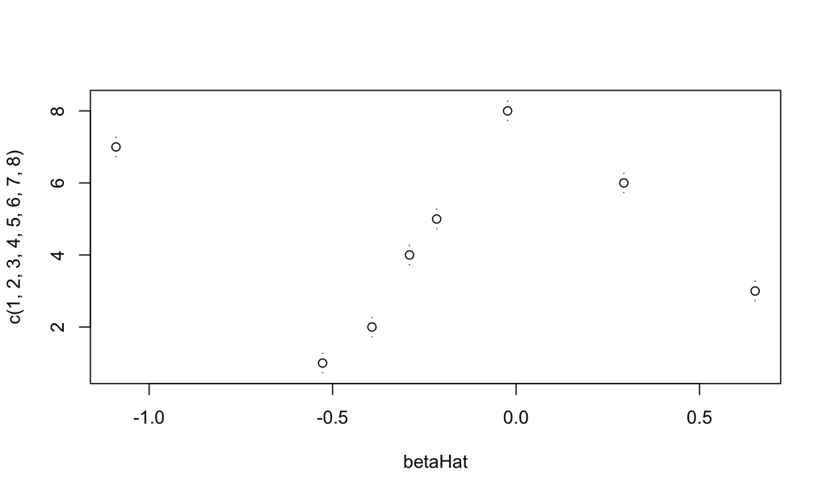

```r
n = 33; p = 8
alpha <- (n - p -1)/2
alphaHat <- mean(y)
betaHat <- solve(t(X) %*% X) %*% t(X) %*% (y - mean(y))
one <- rep(1,33)
s2 <- t(y - alphaHat *(one) - X %*% betaHat)%*%
  (y - alphaHat * (one) - X %*% betaHat)
beta <- s2/2
postVarSigma <- sqrt((beta)^2/((alpha-1)^2%*%(alpha-2)))
plotCI(x = betaHat,  y=  c(1,2,3,4,5,6,7,8), uiw=
    postVarSigma)
```

## Semi-noninfomative solution

- Can use a conjugate prior family of the form

\[\begin{aligned} (\alpha,\beta) \mid \sigma^2 &\sim N_{p+1} (\tilde{\alpha},\tilde{\beta}, \sigma^2 M^{-1}) \\ \sigma^2 &\sim \text{InverseGamma}(a,b), \end{aligned} \] where \(a,b > 0\) and \(M_{p+1, p+1}\) is a postive definite symmetric matrix.

- However, we will not move into this more as the posterior variances are sensitives the the choices of \(M, a, b\) known as hyper-parameters.

## Zellner's G-prior

- Allow the experimenter to introduce (possibly weak) information about the location parameter of the regression but to bypass the most difficult aspects of the prior specification

\[ \beta \mid \alpha, \sigma^2 \sim N(\tilde{beta}, g\; \sigma^2 (X^TX)^{-1})\]

\[ \pi (\alpha, \sigma^2 ) \propto \sigma^{-2}.\]

## Zellner's G-prior

- G-prior: decomposed as a (conditional) Gaussian prior for \(\beta\) and an improper (Jeffreys) prior for \(\alpha, \sigma^2\).
- This modelling somehow appears as a data-dependent prior through its dependence on \(X,\) but this is not a genuine issue since the whole model is conditional on \(X.\)
- You restrict prior determination to the choices of \(\tilde{\beta}\) and the constant \(g.\)
- The factor g can be interpreted as being inversely proportional to the amount of information available in the prior relative to the sample.
- For instance, setting g = n gives the prior the same weight as one observation of the sample.

## The BayesReg Function

bayesReg function implements Zellner's G-prior.

```r
BayesReg(y, X, g=length(y),  betatilde = rep(0, dim(X)[2]))
```

```
##
##           PostMean PostStError Log10bf EvidAgaH0
## Intercept  -0.8133      0.1407
## x1         -0.5039      0.1883  0.7224      (**)
## x2         -0.3755      0.1508  0.5392      (**)
## x3          0.6225      0.3436 -0.0443
## x4         -0.2776      0.2804 -0.5422
## x5         -0.2069      0.1499 -0.3378
## x6          0.2806      0.4760 -0.6857
## x7         -1.0420      0.4178  0.5435      (**)
## x8         -0.0221      0.1531 -0.7609
##
##
## Posterior Mean of Sigma2: 0.6528
## Posterior StError of Sigma2: 0.939
```

```
## $postmeancoeff
## [1] -0.81328069 -0.50390377 -0.37548142  0.62252447 -0.27762947 -0.20688023
## [7]  0.28061938 -1.04204277 -0.02209411
##
## $postsqrtcoeff
##                  x1        x2        x3        x4        x5        x6
## 0.1406514 0.1882559 0.1508271 0.3436217 0.2803657 0.1498641 0.4759505
##        x7        x8
## 0.4178148 0.1530573
##
## $log10bf
## [1]  0.72241000  0.53918250 -0.04430805 -0.54224765 -0.33779821 -0.68568404
## [7]  0.54353138 -0.76091468
##
## $postmeansigma2
## [1] 0.6528327
##
## $postvarsigma2
## [1] 0.8817734
```

## Next Time

- Model Comparison
- Bayes' Factors
- Bayesian Model Averaging